# NBA Player Props - Daily Betting Guide

Random Forest Model (tracking Elastic Net)

January 15, 2026 at 06:29 AM ET

#### 6 AM Results Update

Focus: Yesterday’s bet results and performance tracking.

**Today’s predictions will be available after the 10 AM ET line scrape.**

# Executive Summary

### Quick Action Items

**14 HIGH confidence picks today**

- Shaedon Sharpe UNDER 25.5 @ -145 (Bovada) - 6.6 pt edge
- Keyonte George UNDER 25.5 @ -145 (Bovada) - 6.3 pt edge
- Shaedon Sharpe UNDER 24.5 @ -101 (BetOnline) - 5.6 pt edge

**17 MEDIUM** confidence picks also available (see below)

43  
Total Picks

14  
High Conf

3.7  
Avg Edge (pts)

# Bets

## Today’s Picks

### Quick Decision Guide

| Confidence | Count | Action |
| --- | --- | --- |
| **HIGH** | 14 | Bet these first |
| **MEDIUM** | 17 | Bet if bankroll allows |
| Avoid | 12 | Do not bet |

### High-Value Alerts

#### HIGH-VALUE OPPORTUNITIES

**Shaedon Sharpe** - Under 25.5 @ -145 (Bovada)  
Edge: 6.6 pts | Win Prob: ~58%

**Keyonte George** - Under 25.5 @ -145 (Bovada)  
Edge: 6.3 pts | Win Prob: ~58%

**Shaedon Sharpe** - Under 24.5 @ -101 (BetOnline)  
Edge: 5.6 pts | Win Prob: ~57%

**Keyonte George** - Under 24.5 @ -115 (Hard Rock)  
Edge: 5.3 pts | Win Prob: ~57%

**Jalen Johnson** - Under 24.5 @ -145 (Bovada)  
Edge: 4.9 pts | Win Prob: ~57%

### HIGH Confidence Bets

| Player | Team | Bet | Our Prediction | Edge | Odds | Book | Game | Time |
| --- | --- | --- | --- | --- | --- | --- | --- | --- |
| Shaedon Sharpe | POR | Under 25.5 | 18.9 | 6.6 pts | -145 | Bovada | Atlanta Hawks @ Portland Trail Blazers | Jan 15 10:10 PM |
| Keyonte George | UTA | Under 25.5 | 19.2 | 6.3 pts | -145 | Bovada | Utah Jazz @ Dallas Mavericks | Jan 15 10:10 PM |
| Shaedon Sharpe | POR | Under 24.5 | 18.9 | 5.6 pts | -101 | BetOnline | Atlanta Hawks @ Portland Trail Blazers | Jan 15 10:10 PM |
| Keyonte George | UTA | Under 24.5 | 19.2 | 5.3 pts | -115 | Hard Rock | Utah Jazz @ Dallas Mavericks | Jan 15 10:10 PM |
| Jalen Johnson | ATL | Under 24.5 | 19.6 | 4.9 pts | -145 | Bovada | Atlanta Hawks @ Portland Trail Blazers | Jan 15 10:10 PM |
| Shaedon Sharpe | POR | Under 23.5 | 18.9 | 4.6 pts | 105 | Bovada | Atlanta Hawks @ Portland Trail Blazers | Jan 15 10:10 PM |
| Nickeil Alexander-Walker | ATL | Under 21.5 | 17.1 | 4.4 pts | -130 | Bovada | Atlanta Hawks @ Portland Trail Blazers | Jan 15 10:10 PM |
| Keyonte George | UTA | Under 23.5 | 19.2 | 4.3 pts | 105 | Bovada | Utah Jazz @ Dallas Mavericks | Jan 15 10:10 PM |
| Jaylen Brown | BOS | Under 30.5 | 26.6 | 3.9 pts | -135 | Bovada | Boston Celtics @ Miami Heat | Jan 15 10:10 PM |
| Jalen Johnson | ATL | Under 23.5 | 19.6 | 3.9 pts | -116 | DraftKings | Atlanta Hawks @ Portland Trail Blazers | Jan 15 10:10 PM |

[output cut: 4 more lines]

### MEDIUM Confidence Bets

| Player | Team | Bet | Our Prediction | Edge | Odds | Book | Game | Time |
| --- | --- | --- | --- | --- | --- | --- | --- | --- |
| Nickeil Alexander-Walker | ATL | Under 20.5 | 17.1 | 3.4 pts | -104 | DraftKings | Atlanta Hawks @ Portland Trail Blazers | Jan 15 10:10 PM |
| Cade Cunningham | DET | Under 28.5 | 25.2 | 3.3 pts | -150 | Bovada | Phoenix Suns @ Detroit Pistons | Jan 15 10:10 PM |
| Keyonte George | UTA | Under 22.5 | 19.2 | 3.3 pts | 125 | Bovada | Utah Jazz @ Dallas Mavericks | Jan 15 10:10 PM |
| Payton Pritchard | BOS | Under 17.5 | 14.3 | 3.2 pts | -150 | Bovada | Boston Celtics @ Miami Heat | Jan 15 10:10 PM |
| Shai Gilgeous-Alexander | OKC | Under 32.5 | 29.4 | 3.1 pts | -150 | Bovada | Oklahoma City Thunder @ Houston Rockets | Jan 15 10:10 PM |
| Jock Landale | MEM | Under 12.5 | 9.4 | 3.1 pts | -130 | ESPN Bet | Memphis Grizzlies @ Orlando Magic | Jan 15 10:10 PM |
| Jaylen Brown | BOS | Under 29.5 | 26.6 | 2.9 pts | -110 | Hard Rock | Boston Celtics @ Miami Heat | Jan 15 10:10 PM |
| Grayson Allen | PHX | Under 14.5 | 11.6 | 2.9 pts | -125 | ESPN Bet | Phoenix Suns @ Detroit Pistons | Jan 15 10:10 PM |
| Jalen Johnson | ATL | Under 22.5 | 19.6 | 2.9 pts | 105 | Bovada | Atlanta Hawks @ Portland Trail Blazers | Jan 15 10:10 PM |
| Karl-Anthony Towns | NYK | Under 22.5 | 19.7 | 2.8 pts | -103 | DraftKings | New York Knicks @ Golden State Warriors | Jan 15 10:10 PM |

[output cut: 7 more lines]

## All Bets

| Player | Team | Bet | Our Prediction | Edge | Odds | Book | Game | Time | Conf |
| --- | --- | --- | --- | --- | --- | --- | --- | --- | --- |
| Shaedon Sharpe | POR | Under 25.5 | 18.9 | 6.6 pts | -145 | Bovada | Atlanta Hawks @ Portland Trail Blazers | Jan 15 10:10 PM | High |
| Keyonte George | UTA | Under 25.5 | 19.2 | 6.3 pts | -145 | Bovada | Utah Jazz @ Dallas Mavericks | Jan 15 10:10 PM | High |
| Shaedon Sharpe | POR | Under 24.5 | 18.9 | 5.6 pts | -101 | BetOnline | Atlanta Hawks @ Portland Trail Blazers | Jan 15 10:10 PM | High |
| Keyonte George | UTA | Under 24.5 | 19.2 | 5.3 pts | -115 | Hard Rock | Utah Jazz @ Dallas Mavericks | Jan 15 10:10 PM | High |
| Jalen Johnson | ATL | Under 24.5 | 19.6 | 4.9 pts | -145 | Bovada | Atlanta Hawks @ Portland Trail Blazers | Jan 15 10:10 PM | High |
| Shaedon Sharpe | POR | Under 23.5 | 18.9 | 4.6 pts | 105 | Bovada | Atlanta Hawks @ Portland Trail Blazers | Jan 15 10:10 PM | High |
| Nickeil Alexander-Walker | ATL | Under 21.5 | 17.1 | 4.4 pts | -130 | Bovada | Atlanta Hawks @ Portland Trail Blazers | Jan 15 10:10 PM | High |
| Keyonte George | UTA | Under 23.5 | 19.2 | 4.3 pts | 105 | Bovada | Utah Jazz @ Dallas Mavericks | Jan 15 10:10 PM | High |
| Jaylen Brown | BOS | Under 30.5 | 26.6 | 3.9 pts | -135 | Bovada | Boston Celtics @ Miami Heat | Jan 15 10:10 PM | High |
| Jalen Johnson | ATL | Under 23.5 | 19.6 | 3.9 pts | -116 | DraftKings | Atlanta Hawks @ Portland Trail Blazers | Jan 15 10:10 PM | High |

[output cut: 33 more lines]

## Yesterday’s Results

No results available for January 14, 2026. This may be because:

- No games were played yesterday
- Player stats haven’t been updated yet
- Historical lines data doesn’t include yesterday

## Betting Rules

| Rule | Requirement | Why |
| --- | --- | --- |
| **Bet Type** | UNDERS ONLY | Model predicts regression, not breakouts |
| **Edge** | 3+ points | Smaller edges don’t overcome vig |
| **Odds** | -115 or better | Worse odds = losing money |
| **Confidence** | HIGH or MEDIUM | LOW/AVOID = break-even or worse |

### Expected Results

[output not shown]

# Analysis

## P&L Over Time

This chart shows the cumulative profit/loss if you had followed each strategy from the start of our data.

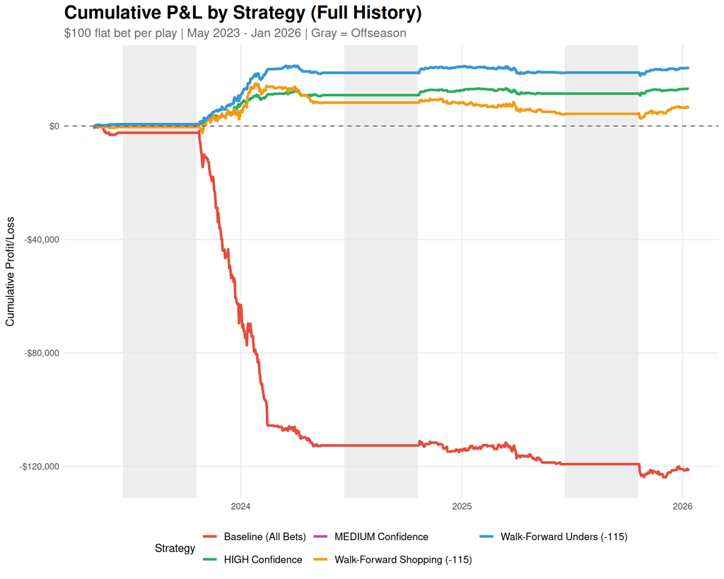

## P&L By Season

Each season starts at $0. This shows how each strategy performed within each NBA season.

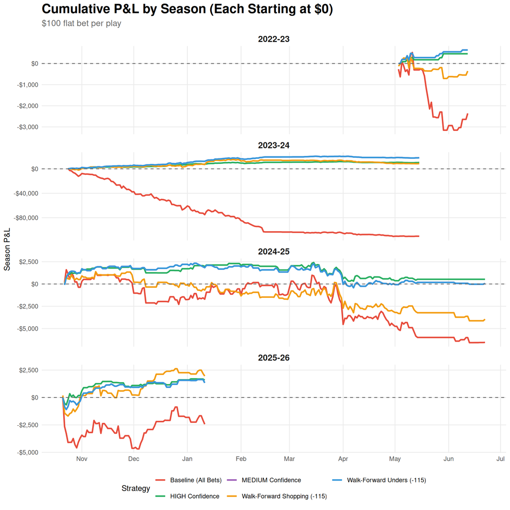

## Season Summary

| Season | Strategy | Bets | Wins | Win % | P&L | ROI |
| --- | --- | --- | --- | --- | --- | --- |
| 2022-23 | MEDIUM Confidence | 17 | 12 | 70.6 | 639 | 37.6 |
| 2022-23 | Walk-Forward Unders (-115) | 17 | 12 | 70.6 | 639 | 37.6 |
| 2022-23 | HIGH Confidence | 9 | 7 | 77.8 | 461 | 51.2 |
| 2022-23 | Walk-Forward Shopping (-115) | 101 | 50 | 49.5 | -359 | -3.6 |
| 2022-23 | Baseline (All Bets) | 591 | 374 | 63.3 | -2361 | -4 |
| 2023-24 | MEDIUM Confidence | 1521 | 848 | 55.8 | 18137 | 11.9 |
| 2023-24 | Walk-Forward Unders (-115) | 1521 | 848 | 55.8 | 18137 | 11.9 |
| 2023-24 | HIGH Confidence | 859 | 487 | 56.7 | 10435 | 12.1 |
| 2023-24 | Walk-Forward Shopping (-115) | 4529 | 2289 | 50.5 | 8606 | 1.9 |
| 2023-24 | Baseline (All Bets) | 23104 | 14107 | 61.1 | -110290 | -4.8 |

[output cut: 10 more lines]

## Current Season

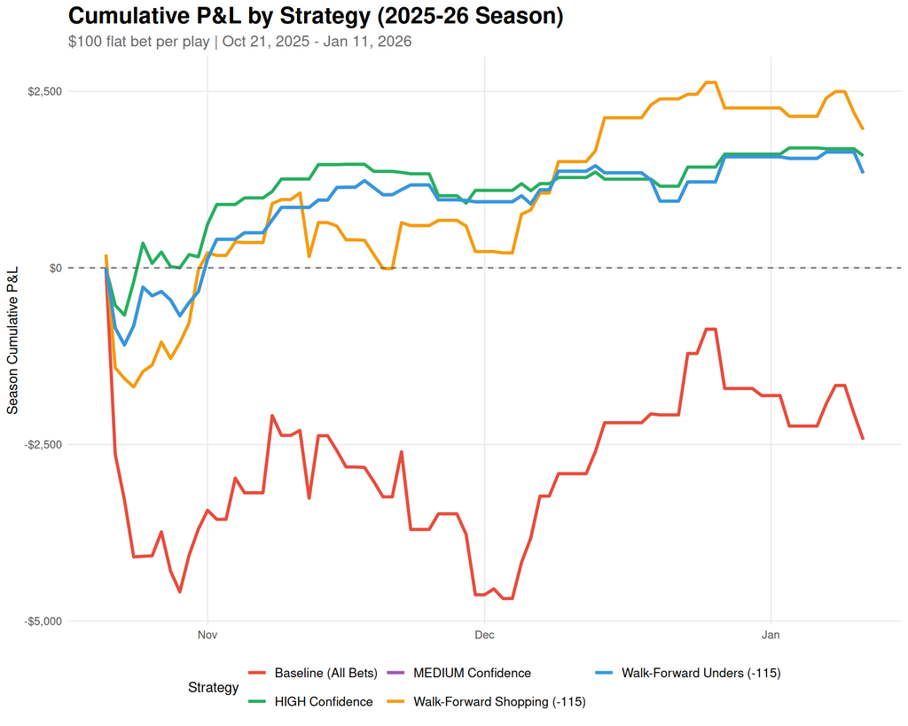

## Unders vs Overs

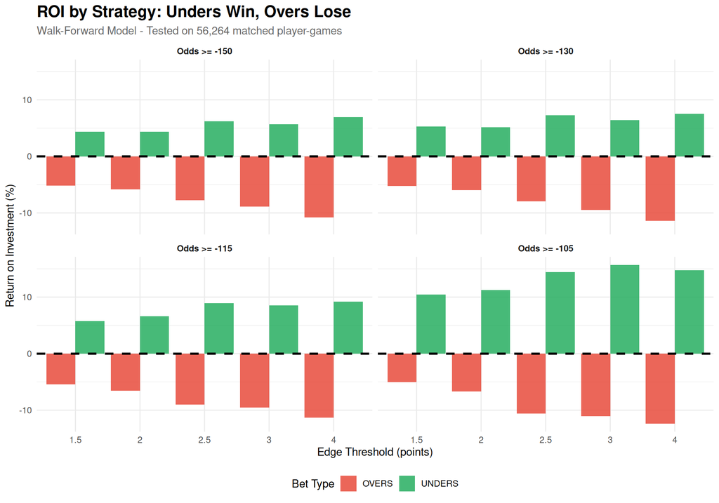

## Win Rate

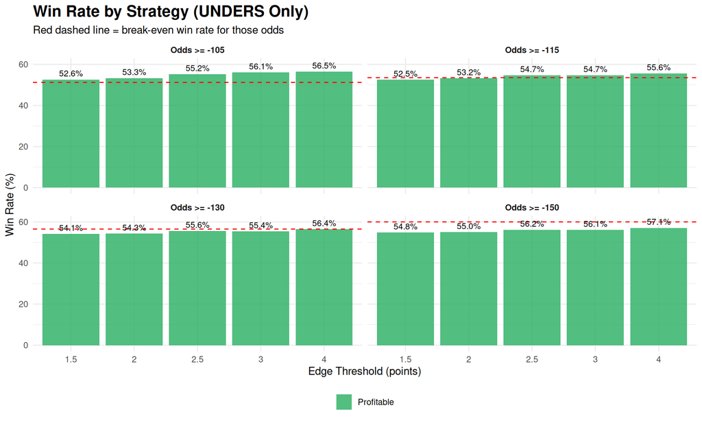

## Volume vs ROI

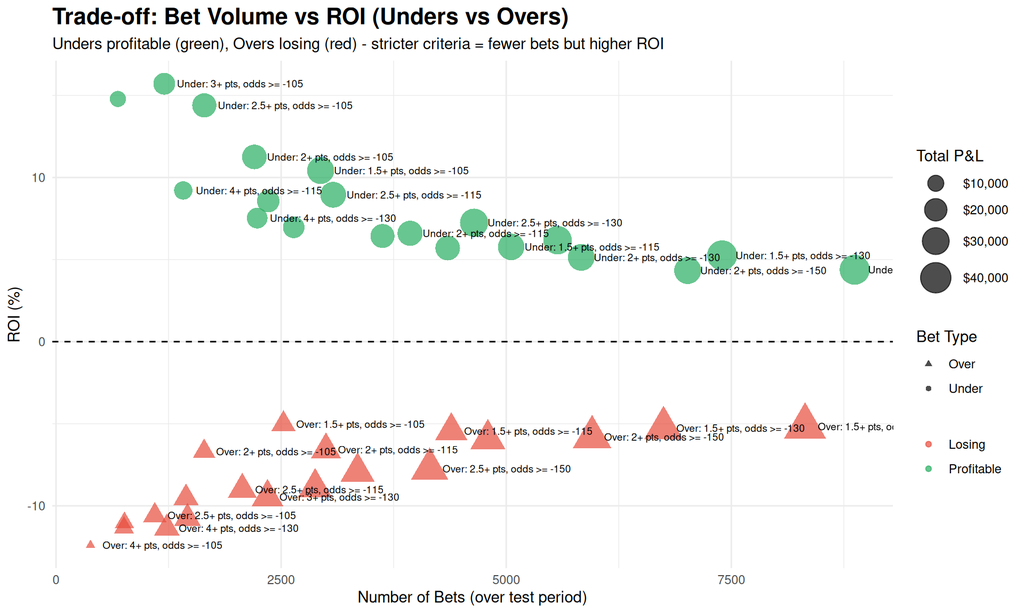

## Monthly P&L

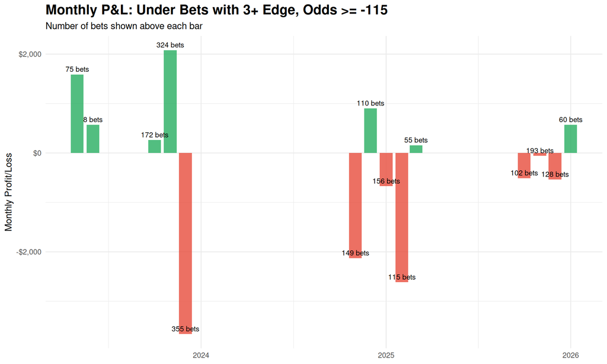

## Sportsbooks

### Lines by Book

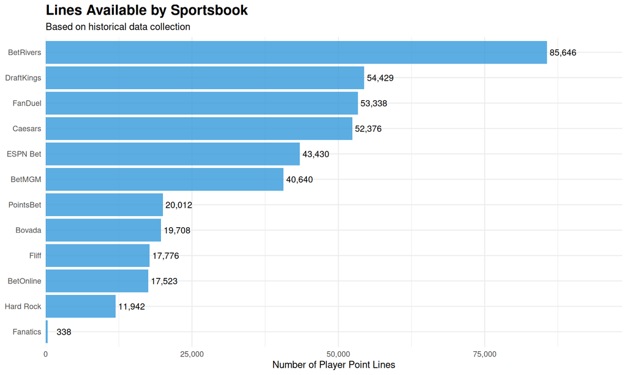

### Best Odds by Book

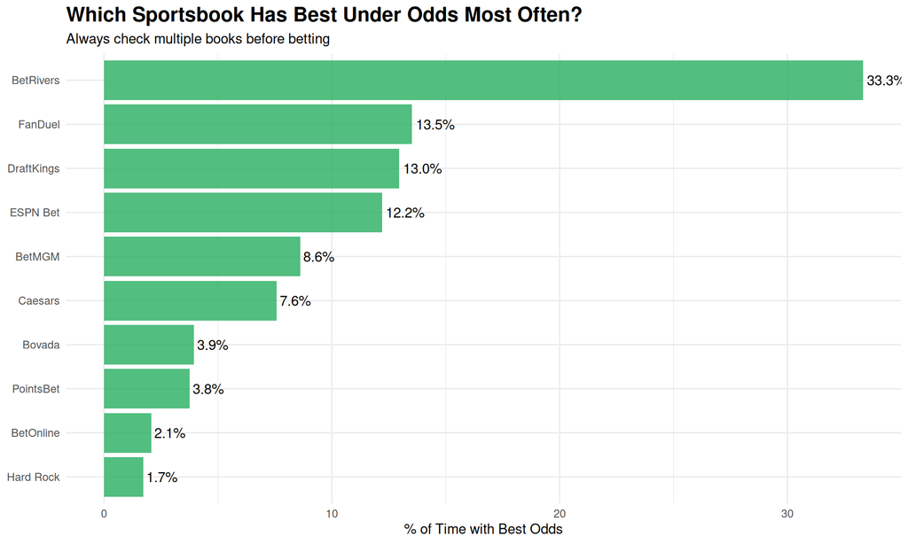

### Odds Distribution

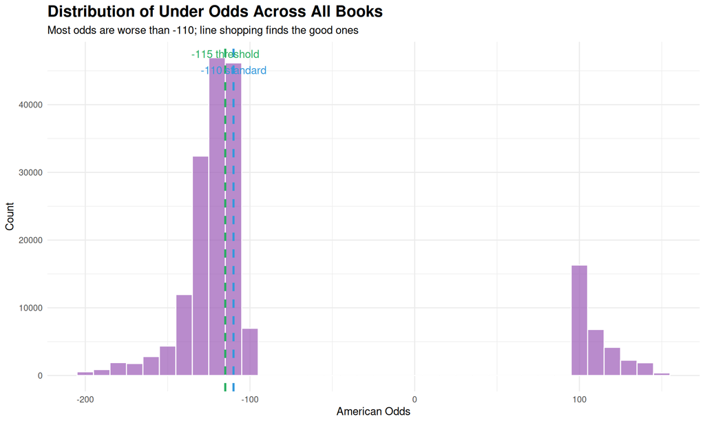

*Report generated: 2026-01-15 06:29:14 AM ET*